# Technical White Paper: Macro-PCA Portfolio Optimization

1. Executive Summary
2. Data Pipeline Architecture
3. PCA Engine & Latent Factor Extraction
4. Tactical Asset Allocation Logic
5. Backtest Validation & Results
6. Conclusion

## 1. Executive Summary

This report details the methodology of a macro-driven tactical asset allocation strategy. By synthesizing a panel of high-frequency macroeconomic indicators using Principal Component Analysis (PCA), we extract the “latent” economic signal. This signal is then mapped through a smooth logistic function to drive high-precision portfolio weighting, significantly improving risk-adjusted returns (Sharpe Ratio) and limiting maximum drawdowns during economic contractions.

## 2. Data Pipeline Architecture

### 2.1 Indicators Panel

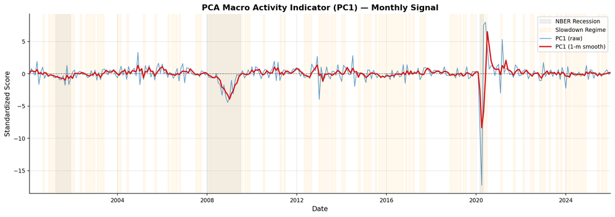

PC1 Signal Strengths

## 3. PCA Engine & Latent Factor Extraction

We apply **Principal Component Analysis (PCA)** to the standardized matrix. * **Sign Alignment**: We ensure the PC1 sign is negative during recessions. * **Variance Explained**: The primary factor (PC1) captures the “synchronized” movement of the economy.

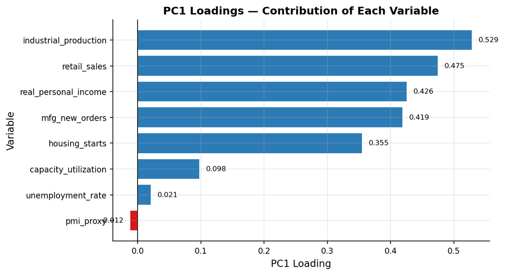

Factor Loadings

## 4. Tactical Asset Allocation Logic

### 4.1 Logistic Risk Score

Instead of binary flips, we apply a smooth mapping to determine the **Risk Score (0-1)**:

$$R_t = \frac{1}{1 + e^{(S_t - c) /
k}}$$

### 4.2 Dynamic Equity Weighting

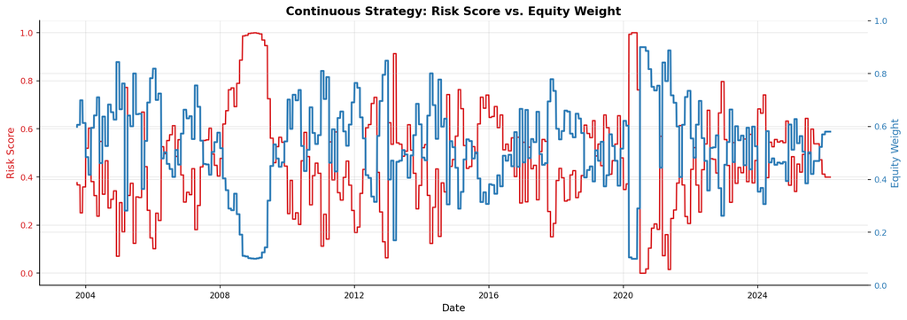

Risk vs Weights Chart

## 5. Backtest Validation & Results

| Metric | Benchmark (60/40) | **Macro-PCA (Continuous)** |
| --- | --- | --- |
| **Sharpe Ratio** | 0.73 | **0.98** |
| **Max Drawdown** | -34.70% | **-20.74%** |

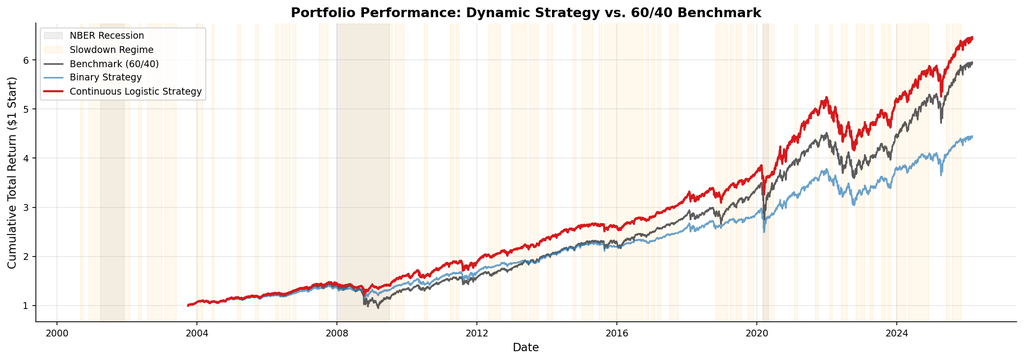

Portfolio Cumulative Returns

## 6. Conclusion

The Macro-PCA approach bridge the gap between economic theory and practical investment management. It provides an objective, data-driven framework for de-risking portfolios before financial markets fully price in a recession.